# Dokumentacja

Dokumentacja

- Spis użytych technologii
- Opis plików
- Kolejność uruchamiania plików
- Schemat projektu
- Zależności funkcyjne
- Baza EKNF
- Co sprawiło nam najwiekszą trudność?

**Spis użytych technologii**

Do zarządzania bazą danych wykorzystałyśmy MariaDB/MySQL, natomiast skrypty do obsługi bazy i generowania danych napisałyśmy w Pythonie. Analizę danych napisałyśmy w SQL.  
W procesie używałyśmy kilku biblotek: mysql.connector, random, datetime, matplotlib.  
Raport stworzyłyśmy używając programu Quarto, w którym wykorzystałyśmy Pythona integrując go z bazą danych.  
Do stworzenia schematu projektu wykorzystałyśmy narzędzie DrawSQL.

**Opis plików**

Projekt podzieliłyśmy na kilka plików.  
Plik "tworzenie_bazy" jest plikiem napisanym w SQL, który najpierw usuwa wszystkie tabelki, jeżeli takie istnieją, a następnie tworzy puste tabelki od początku.  
Następnymi plikami są skrypty w Pythonie, gdzie z pomocą biblioteki *mysql.connector* generujemy dane do bazy. Do wypełnienia niektórych tabelek używamy dodatkowych plików, które znajdują się w folderze txt_folder. Pliki zawierają nazwy ulic, imiona, nazwiska, które pobrałyśmy ze strony GOV.pl.  
Kolejnym plikiem jest "Analiza_danych", w którym wykonujemy zapytania do bazy.  
W następnym pliku "Raport" wykorzystujemy uzyskane informacje z wykonanej analizy danych do opisu m.in. perspektyw firmy i preferencji klientów.

**Kolejność uruchamiania plików**

**Schemat projektu**

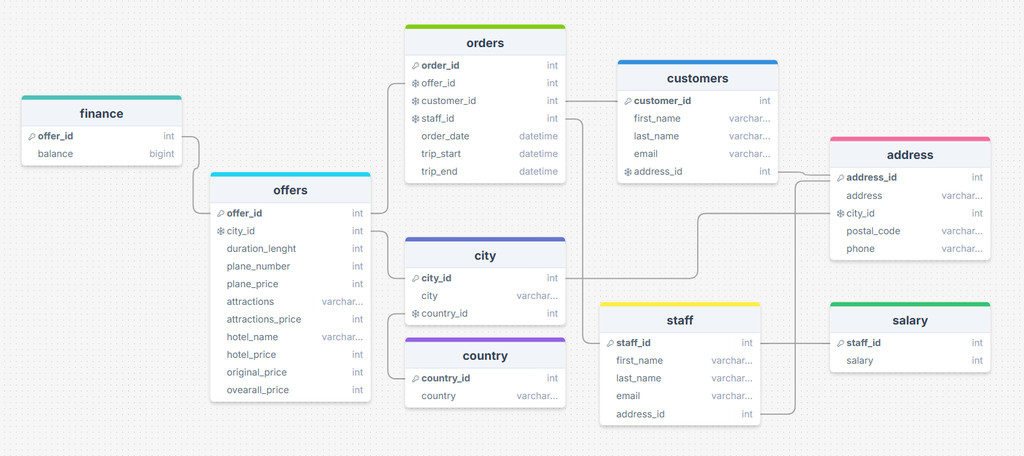

**Zależności funkcyjne**

Zależność funkcyjna w bazie danych oznacza, że wartość jednego atrybutu jednoznacznie określa wartość innego atrybutu w tej samej tabeli. W naszej bazie tabelki mają pełną zależność funkcyjną. Omówimy zależności funkcyjne dla każdej naszej tabelki. W naszych tabelkach korzystałyśmy z kluczy główny (primary key) oraz kluczy zapożyczony (foreign key). Omówimy każdą tabelkę.

**Address**

- address_id (primary key), city_id (foreign key)
- łączy się z tabelką staff, customers oraz city
- zależności funkcyjne: address_id --> address, city_id, postal-code, phone

**City**

- city_id (primary key), country_id (foreign key)
- poza tabelką adressses łączy się z country i offers
- zależności funkcyjne: city_id --> city, country_id

**Country**

- country_id (primary key)
- łączy się tylko z tabelką city
- zależności funkcyjne: country_id --> country

**Customers**

- customer_id (primary key), address_id (foreign key)
- łączy się z address, orders
- zależności funkcyjne: customer_id --> first_name, last_name, email, address_id

**Finance**

- offer_id (foreign key)
- łączy się z tylko z offers
- zależności funkcyjne: offer_id --> balance

**Offers**

- offer_id (primary key), city_id (foreign key)
- łączy się z tabekami finance, orders i city
- zależności funkcyjne: offer_id --> city_id, duration_length, plane_number, plane_price, attractions, attractions_price, hotel_name, hotel_price, original_price, overall_price

**Orders**

- order_id (primary key), offer_id, customer_id, staff_id (foreign key)
- łączy się z offers, customers oraz staff
- zależności funkcyjne: order_id --> offer_id, customer_id, staff_id, order_date, trip_start, trip_end

**Salary**

- staff_id (foreign key)
- łączy się z jedynie z staff
- zależności funkcyjne: staff_id --> salary

**Uzasadnienie, że baza jest w EKNF**

1NF  
Aby relacja była w 1NF, musi spełniać następujące warunki:  
- każdy atrybut przechowuje tylko jedną wartość (atomowość),  
- wiersze muszą być unikalne (mieć klucz główny),  
- wszystkie atrybuty muszą reprezentować pojedynczy typ danych.

2NF  
Relacja jest w 2NF, jeśli:  
- spełnia 1NF,  
- każdy atrybut niekluczowy zależy całkowicie od klucza głównego (nie od jego części).

3NF  
Relacja jest w 3NF, jeśli:  
- spełnia 2NF,  
- nie ma zależności przechodnich (tj. atrybuty niekluczowe nie zależą od innych atrybutów niekluczowych).

EKNF (Ekstremalna Kluczowa Normalna Forma)  
Baza danych spełnia EKNF, jeśli:  
- jest w 3NF,  
- każda nietrywialna zależność funkcyjna X → A (gdzie A nie należy do X) zachodzi, gdy X jest nadkluczem.

EKNF eliminuje subtelne anomalie obecne w 3NF, co zapewnia jeszcze lepszą jakość danych i unika problemów z niepełnymi kluczami.  
Dlatego warto tworzyć bazy w EKNF.

I my tak właśnie zrobiłyśmy, co udowodnimy na podstawie tabelki *customers*.  
W tabelce *customers* kluczem głównym jest tylko *customer_id*. Tylko od klucza głównego zależy jakie są wartości w innych kolumnach, np. znając *first_name* nie możemy nic wywnioskować na temat wartości w innych kolumnach, ponieważ imiona mogą się powtarzać. I tak samo jest z kolumnami *last_name*, *email* oraz *address_id*.  
Zgodnie z założeniami EKNF między każdymi dwoma tabelkami jest tylko jedno połączenie, czyli nie ma duplikacji danych.

**Co sprawiło nam najwiekszą trudność?**

Najtrudniejsze dla nas okazało się być stworzenie schematu bazy danych i połączeń między tabelkami.  
Ciężkie również było zaimplementowanie bazy w EKNF.